# Time Series: A First Course with Bootstrap Starter

# Lesson 8-3: Maximum Entropy

- We discuss the maximum entropy principle.

## Paradigm 8.3.1. Maximum Entropy Principle

- If the parameters of a distribution are chosen so as to maximize entropy, we guard against a worst-case scenario for the state of nature.
- So we seek to maximize entropy subject to the observed data.

## Example 8.3.2. Bernoulli Maximum Entropy

- In Example 8.1.10 with a Bernoulli random variable, if we have no data the maximum entropy principle yields $p=1/2$.
- If we observed $X=1$, we would instead say $p=1$.

## Definition 8.3.5.

Given two continuous random variables $X$ and $Y$ with probability density functions $p$ and $q$ respectively, the **relative entropy** of $X$ to $Y$ is
$$H(X; Y) = - \int p(x) \, \log \left( \frac{ q(x) }{p(x)} \right) \, dx
= - \int p(x) \log q(x) \, dx - H(X).$$
By Jensen’s inequality, $H(X;Y) \geq 0$ and equals zero iff $X$ and $Y$ have the same distribution.

## Example 8.3.8. Gaussian has Maximum Entropy given its Variance

- Suppose that $X$ is a continuous random variable with pdf $p$, and has mean zero and variance $\sigma^2$.
- Let $Y \sim \mathcal{N} (0, \sigma^2)$, but with pdf $q$.
- Then $\log q(x) = -.5 \log (2 \pi) - .5 x^2/\sigma^2$, and
  $$-\int p(x) \, \log q(x) \, dx = .5 \log (2 \pi) + .5 \sigma^{-2} \int
  x^2 p(x) dx
  = .5 (1 + \log (2 \pi)).$$
- The relative entropy is
  $$H(X;Y) = - \int p(x) \, \log q(x) \, dx - H(X) =
  .5 (1 + \log (2 \pi)) - H(X).$$
- Since relative entropy is non-negative, we find that $H(X) \leq .5 (1 + \log (2 \pi))$. This is a bound on any such $X$, and the Gaussian attains this upper bound (since $H(Y) = .5 (1 + \log (2 \pi))$). Hence the Gaussian has maximum entropy.

## Remark 8.3.10. Redundancy Lowers Entropy

- By Fact 8.3.9, entropy increases linearly in sample size for a random sample.
- When dependence is full, then $H(\underline{X}) = H(X_1)$ instead.
- So redundancy (full dependence) lowers entropy.
- By the maximum entropy principle, serial independence is favored over dependence on a priori grounds.

## Definition 8.3.11.

- A transformation $\Xi$ that maps $\underline{X}$ to $\Xi [ \underline{X}]$ is *entropy-increasing* if
  $$H \left( \Xi [ \underline{X}] \right) > H (\underline{X}).$$
- For instance: $\Xi$ decorrelates (reduces dependence), $\Xi$ preserves variance while transforming marginal structure to Gaussian.

## Example 8.3.12. Whitening as an Entropy-Increasing Transformation

- Suppose $\underline{X} \sim \mathcal{N}(0, \Sigma)$. We want to decorrelate $\underline{X}$, and see how entropy changes.
- Let $D$ denote the diagonal entries of $\Sigma$. Let $L L^{\prime} = \Sigma$ be the Cholesky decomposition. Then $\underline{Y} = D^{1/2} L^{-1} \underline{X} \sim \mathcal{N}(0, D)$.
- So $\underline{Y} = \Xi [ \underline{X}]$ has been decorrelated.
- Comparing entropies:
  $$H(\underline{X}) - H (\underline{Y}) = .5 \log \det \Sigma - .5 \log
  \det D
  = .5 \log \det \left( D^{-1/2} \Sigma D^{-1/2} \right).$$
- The matrix $R = D^{-1/2} \Sigma D^{-1/2}$ is a correlation matrix, and has determinant between $0$ and $1$. Hence $H(\underline{X}) \leq H(\underline{Y})$, and inequality is strict unless $\det R = 1$.

### Illustration of Example 8.3.12.

- Consider the bivariate normal $\underline{X}$ with mean zero and variance
  $$\Sigma = \left[ \begin{array}{cc} 2 & 3 \\ 3 & 5 \end{array}
  \right].$$
- So $D = \mbox{diag} [ 2,5]$.
- We print the entropies of $\underline{X}$ and $\underline{Y} = D^{1/2} L^{-1} \underline{X}$.

```r
Sigma <- rbind(c(2,3),c(3,5))
D <- diag(Sigma)
L <- t(chol(Sigma))
ents <- c(log(1 + 2*pi ) + .5*log(det(Sigma)), log(1 + 2*pi ) + .5*sum(log(D)))
print(ents)
```

```
## [1] 1.985568 3.136861
```

- We simulate 100 draws of $\underline{X}$, construct the decorrelated $\underline{Y}$, and generate both scatterplots.

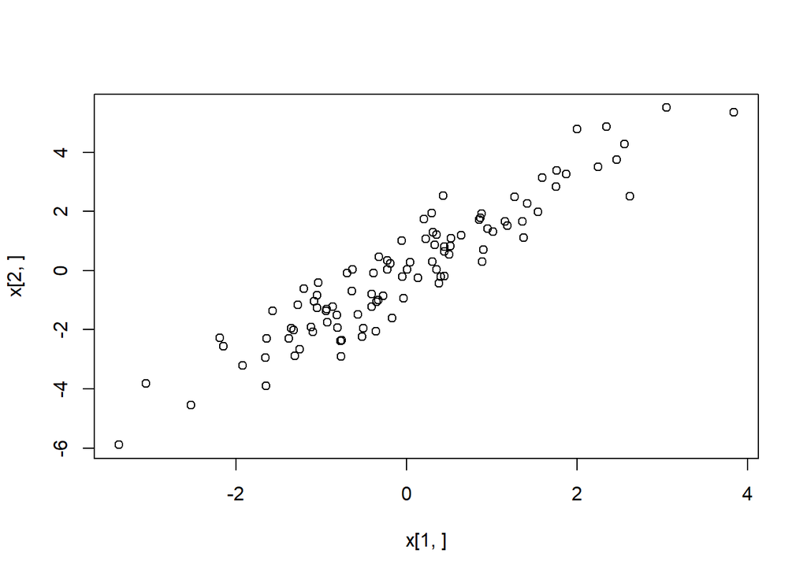

```r
x <- L %*% matrix(rnorm(2*100),nrow=2)
y <- diag(sqrt(D)) %*% solve(L) %*% x
plot(x[1,],x[2,])
```

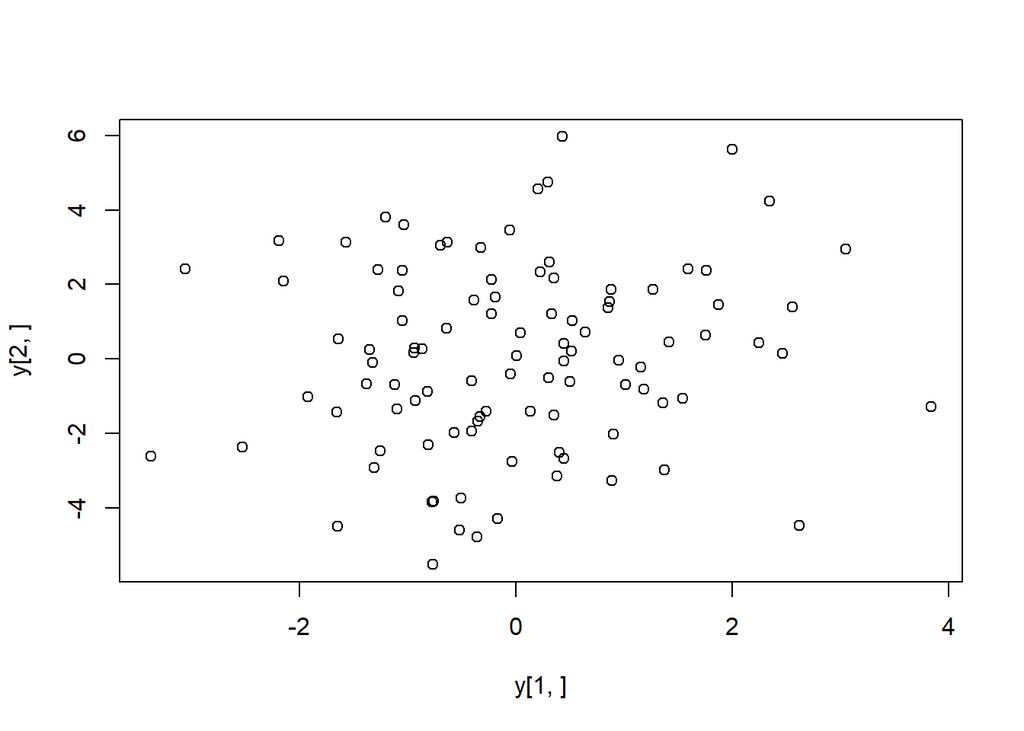

```r
plot(y[1,],y[2,])
```